# Интерактивная среда разработки IPython

IPython - интерактивная оболочка для языка программирования Python. Создал IPython физик Фернандо Перез. Идея интерфейса блокнота для IPython была взята у Mathematica. Перез восхищался тем, как блокноты в Mathematica поощряли исследовательский стиль работы.

В настоящее время некоторые научные работы публикуются в виде PDF в комплекте с блокнотом IPython. В блокноте можно отследить всю работу, сгенерировавать все графики для статьи. Каждый желающий может сам запустить код, подправить его, чтобы лучше понять, как они работают.

# Jupyter

Проект в 2014-м переименовали в Jupyter, чтобы подчеркнуть, что он работает уже не только с Python.

Jupyter Notebook так же похож на блокнот Mathematica. Подходит для любого языка программирования Можно сделать блокнот для Python, C, R, Ruby, JavaScript, Julia. Сегодня его поддерживает уже более 100 языков.

# Установка Jupyter Notebook

Для установки через conda необходимо набрать следующую команду в командной строке (терминал для Mac/Linux или Command Prompt для Windows):

```
conda install -c conda-forge notebook
```

Для установки через pip необходимо набрать следующую команду в командной строке:

```
pip install notebook
```

# Запуск сервера Notebook и работа с блокнотом

После установки Jupyter Notebook на компьютер необходимо на нем запустить notebook сервер. Для этого необходимо выполнить следующую команду в командной строке:

```
jupyter notebook
```

Данная команда выводит информацию о notebook сервере в теминале, включая URL веб-приложения (по умолчанию http://localhost:8888). Пример текста информации о notebook сервере в теминале:

```
$ jupyter notebook
[I 08:58:24.417 NotebookApp] Serving notebooks from local directory: /Users/catherine
[I 08:58:24.417 NotebookApp] 0 active kernels
[I 08:58:24.417 NotebookApp] The Jupyter Notebook is running at: http://localhost:8888/
[I 08:58:24.417 NotebookApp] Use Control-C to stop this server and shut down all kernels (twice to skip confirmation).
```

Затем откроется веб-браузер по умолчанию для этого URL.

После открытия notebook в браузере, будет показана Notebook Dashboard, которая содержит список notebook, файлов, поддиректорий в директории, где notebook сервер был запущен. Чаще всего notebook сервер запускается в наивысшей директории с необходимыми notebook.

Пример Notebook Dashboard:

[figure not shown]

Для того чтобы создать новый ноутбук необходимо нажать New -> Python 3 и будет создан новый ноутбук для Python 3.

[figure not shown]

По умолчанию файлу присваивается имя Untitle.ipynb. Для переименования файла поставьте галочку напротив имени файла и нажмите на кнопку Rename.

Аналогично происходит создание папок, текстовых файлов и прочих объектов.

В Jupyter Notebook блокнот имеет расширение .ipynb и представляет собой текстовый файл, который хранит содержимое блокнота в формате JSON.

[figure not shown]

Созданный ноутбук будет выглядить следующим образом:

[figure not shown]

Блокнот состоит из набора ячеек. Код на языке Python или текст в нотации Markdown нужно вводить в ячейки. Ячейки бывают двух видов:

- Ячейка кода содержит код, который должен быть выполнен в ядре, и отображает результат выражения последней строки ниже.
- Ячейка Markdown (облегченный язык разметки) содержит текст, отформатированный с использованием Markdown, и отображает его вывод на месте при запуске.

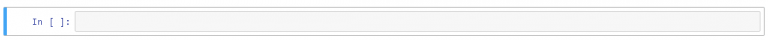

Для создания ячейки с кодом нужно поставить курсор в нужную ячейку и выставить свойство “Code”.

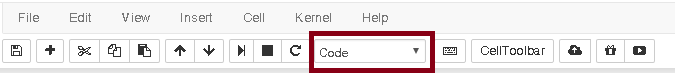

Если это Markdown текст – выставить “Markdown”.

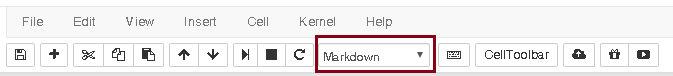

[figure not shown]

У каждого ноутбука есть имя, оно отображается в верхней части экрана. Для изменения имени нажмите на его текущее имя и введите новое.

[figure not shown]

Из элементов интерфейса можно выделить, панель меню:

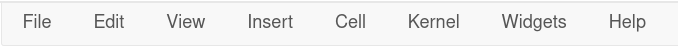

панель инструментов:

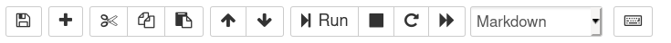

Для создания, удаления, запуска и перемещения (вверх или вниз) ячейки кода необходимо использовать панель инструментов или ледующие сочетания клавиш:

- Ctrl+Enter – выполнить содержимое ячейки.
- Shift+Enter – выполнить содержимое ячейки и перейти на ячейку ниже.
- Alt+Enter – выполнить содержимое ячейки и вставить новую ячейку ниже.

## Порядок выполнения кода в блокноте

В каждом блокноте работает ядро. Во время запуска ячейки кода, этот код выполняется в ядре, и любой вывод возвращается обратно в ячейку для отображения. Состояние ядра сохраняется во времени и между ячейками – оно относится к документу в целом, а не к отдельным ячейкам.

Большую часть времени поток исполнения в ноутбуке будет сверху вниз, но бывают случаи, когда приходится возвращаться, чтобы внести изменения. В этом случае важен порядок выполнения, указанный слева от каждой ячейки.

Пример двух ячеек кода в ноутбуке, выполненых в порядке сверху вниз. Слева указан порядок выполнения ячеек. Jupyter notebook выводит результат выражения последней стоки в ячейке.

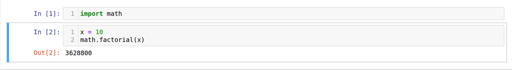

Если с самого начала попытаться запустить ячейки в обратной последовательности, то будет ошибка компиляции так, как в данном пространстве имен еще не была импортирована библиотека math.

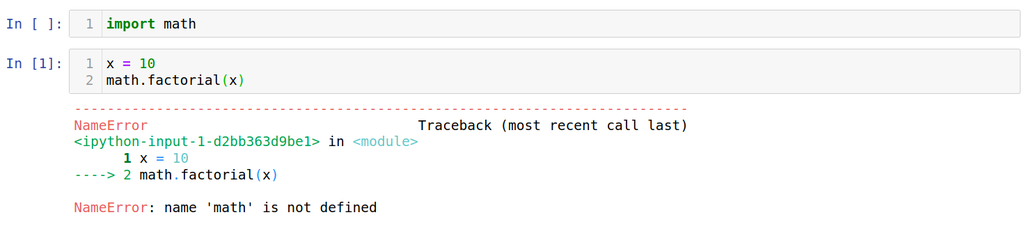

В данной последовательности запуска во второй ячейки в пространстве имен $x = 10$ и только после выполнения третьей ячейки $x = 5$.

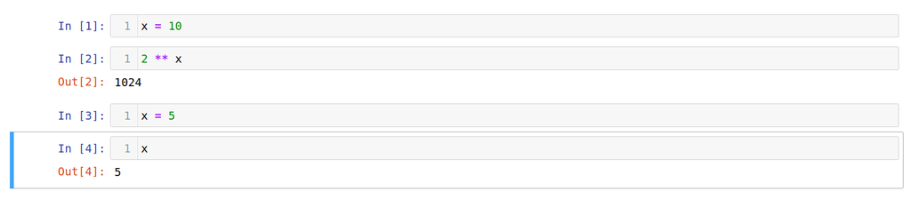

При выполнение сначала третьей ячейки, а затем второй в ней изменяется результат выражения. Так как в пространстве имен на тот момент $x = 5$ и только при выполнение первой ячейки $x = 10$.

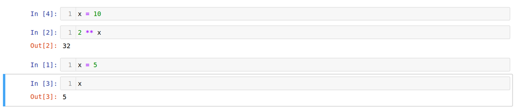

Если нужно сбросить настройки ядра, есть несколько полезных опций из меню Kernel:

- Restart - перезапускает ядро, таким образом очищая все переменные и т.д., которые были определены.
- Restart & Clear Output - то же, что и выше, но также стирает вывод, отображаемый под ячейками кода.
- Restart & Run All - то же, что и выше, но также будет запускать все ячейки ноутбука в порядке от первого до последнего.

[figure not shown]

## Знакомство с параметрами командной строки Notebook сервера

### Как открыть определенный Notebook

Следующая команда открывает заданный notebook на текущем запущенном notebook сервере или запускает notebook сервер в случае необходимости.

```
jupyter notebook notebook.ipynb
```

### Как запустить Notebook сервер на определенном порту.

По умолчанию notebook сервер стартует на 8888 порту. Если порт 8888 не доступен или используется, то notebook сервер запускается на следующем доступном порту. Так же можно указать порт вручную. С помощью следующей команды будет запущен вервер на 9999 порту:

```
jupyter notebook --port 9999
```

# Google Colaboratory

В случае, если не удалось установить Jupyter Notebook, то без потери функциональности можно использовать Google Colaboratory.

Для создания нового ноутбука необходимо перейти по ссылке https://colab.research.google.com/ успешно залогиниться, нажать NEW NOTEBOOK и будет создан новый ноутбук.

[figure not shown]